## CBA Marathon Courses Spring 2019

# Introduction to Python

## Day 2

### Dr. Mohammad AlMarzouq

# Today's Agenda

- Explore different types of data driven applications
- Explore data analysis and visualization capabilities

# Things We Need to Understand

- Webpage Vs. Web Application
- HTTP Vs. HTML
- Webserver Vs. Application Server
- Server-side Vs. Client-side web application
- Micro vs Fullstack web frameworks

# What is a Webpage?

- **Webpage**: A hyperlinked document (i.e. text file) written in HTML/CSS/Javascript that can be viewed in a web browser.
- **Website**: A collection of webpages that are hyperlinked together.
- **Webserver**: The software that serves the webpage files to the browsers over the internet. The browser talks to the webserver using HTTP.

# Webpage Vs. Webapp?

- Webpages are HTML based, and are static.
- We use languages such as Python/PHP/Ruby ..etc to make them dynamic (i.e., change the content depending on who is using it)
- Webservers can only serve static HTML files, so when they get a request for a dynamic page it forwards it to the application server
- Application server generates the HTML on the fly and sends it to the web server to serve to the browser, creating the illusion that HTML is dynamic
- The code we write using languages like Python is the code to generate HTML that users will see

# Server-Side Vs. Client-Side Web Applications?

- With Server-side applications, most of the work done to produce dynamic HTML is done in the application server and served by the webserver.
- Everytime an action is performed the server-side application will have to reload on screen.
- With advances in browser technology, it is now possible to let the browser update the page with new information from the webserver/appserver and make it seem more dynamic
- With new updates from the webserver, the client-side application loads only the portion of the page that changed, and does not reload the whole page

# Web Frameworks

- Group of tools, functions, software, and guideline, if followed, will simplify the development of webapps and provide some guarantees to the developer about the application
- Developers must organize their files in a certain way, or name them a certain way.
- Developers gain by reducing the effort to develop web applications significantly.
- Frameworks differ in the way they standardize development and the benefits they bring to the developer.

# Request/Response Cycle in All Web Applications

1. Browser sends and HTTP request to webserver
2. Webserver forwards the HTTP request to the Application Server
3. Application server gets the user data in the request and performs the required business process
4. The result is prepared as HTML data, included in the HTTP response, and sent back to the webserver
5. The webserver forwards the HTTP response to the browser to display

When you do web application development, you work on steps 3 & 4

# Micro Vs. Fullstack Web Framework

- Micro frameworks are very simplistic, they allow users to handle HTTP requests from webserver and create HTTP responses.
  - Advantage: Simple to learn and deploy, but not feature rich.
  - Example: Flask and Bottle
- Fullstack frameworks offer complete solutions for a data driven web application, including how databases are handled, and how HTML responses are constructed, in addition to a whole host of features.
  - Advantage: Offers numerous features, great for rapid development, but needs time to learn.
  - Example: Django

# Connecting to Databases in Python

- Every database will have its own library
- You establish a connect to the database and store it in a variable
- You execute SQL statements on the conenction, and fetch results (if any) using cursor.

# Sqlite example

- Access and combine data
- Summarize data
- Look for errors
- Transform data
- Segment data
- fetch data from database using sql
- use it as list
- print the data

same data

1. fetch it again from database
2. put it as dataframe
3. display data
4. display visualizations

same data

1. fetch data
2. put it as dataframe
3. display data
4. display visuals
5. show them in web app micro fits with this model

Full stack

1. show ERD and how it is converted into schema
2. show the admin interface crud operations
3. show view operation crud and how it differs from admin

# Our Database Application

- Use Sqlite database
- Single user database, no user credential needed.
- Database is a single file
- Get data [euro soccer data set from kaggle](https://www.kaggle.com/hugomathien/soccer)

```python
# step one: load sqlite library (needed once)
import sqlite3

# step two: establish db conenction (we keep reusing the connection, needed once)
conn = sqlite3.connect("database.sqlite")

#step three: make query using the connection
cur = conn.execute("SELECT * FROM player")

#step four: fetch the result (list of tuples)
result = cur.fetchall()
```

```python
# the results is a list of tuples
result
```

[output not shown]

[output cut: 1894 more lines]

[output not shown]

# Schema

- See [euro soccer data set from kaggle](https://www.kaggle.com/hugomathien/soccer) to get the schema
- You can also use sqlite program to access the database using the command line
- Do a search on the sqlite command and see how you can find the table names and columns in a database

```python
# let's calculate the average weight for all players
# its the last item in each record (tuple)

player_count = len(result)
weight_sum = 0
for record in result:
    weight_sum += record[-1]
print("average is ", weight_sum/player_count)
```

```
average is  168.38028933092224
```

# Let's See What We Can Do With Pandas

- Library for data analysis and visualization
- Data must be organized as a DataFrame
- Makes data analysis convenient (its a framework!)

```python
# we already loaded sqlite and have a connection variable conn
# load pandas

import pandas as pd

player_df = pd.read_sql("SELECT * FROM player", conn)
```

```python
# let's look at the dataframe
player_df

# notice how the column names are now part of the dataframe
# the dataframe is like a db relation
```

|  | id | player_api_id | player_name | player_fifa_api_id | birthday | height | weight |
| --- | --- | --- | --- | --- | --- | --- | --- |
| 0 | 1 | 505942 | Aaron Appindangoye | 218353 | 1992-02-29 00:00:00 | 182.88 | 187 |
| 1 | 2 | 155782 | Aaron Cresswell | 189615 | 1989-12-15 00:00:00 | 170.18 | 146 |
| 2 | 3 | 162549 | Aaron Doran | 186170 | 1991-05-13 00:00:00 | 170.18 | 163 |
| 3 | 4 | 30572 | Aaron Galindo | 140161 | 1982-05-08 00:00:00 | 182.88 | 198 |
| 4 | 5 | 23780 | Aaron Hughes | 17725 | 1979-11-08 00:00:00 | 182.88 | 154 |
| 5 | 6 | 27316 | Aaron Hunt | 158138 | 1986-09-04 00:00:00 | 182.88 | 161 |
| 6 | 7 | 564793 | Aaron Kuhl | 221280 | 1996-01-30 00:00:00 | 172.72 | 146 |
| 7 | 8 | 30895 | Aaron Lennon | 152747 | 1987-04-16 00:00:00 | 165.10 | 139 |
| 8 | 9 | 528212 | Aaron Lennox | 206592 | 1993-02-19 00:00:00 | 190.50 | 181 |
| 9 | 10 | 101042 | Aaron Meijers | 188621 | 1987-10-28 00:00:00 | 175.26 | 170 |
| 10 | 11 | 23889 | Aaron Mokoena | 47189 | 1980-11-25 00:00:00 | 182.88 | 181 |
| 11 | 12 | 231592 | Aaron Mooy | 194958 | 1990-09-15 00:00:00 | 175.26 | 150 |
| 12 | 13 | 163222 | Aaron Muirhead | 213568 | 1990-08-30 00:00:00 | 187.96 | 168 |
| 13 | 14 | 40719 | Aaron Niguez | 183853 | 1989-04-26 00:00:00 | 170.18 | 143 |
| 14 | 15 | 75489 | Aaron Ramsey | 186561 | 1990-12-26 00:00:00 | 177.80 | 154 |
| 15 | 16 | 597948 | Aaron Splaine | 226014 | 1996-10-13 00:00:00 | 172.72 | 163 |
| 16 | 17 | 161644 | Aaron Taylor-Sinclair | 213569 | 1991-04-08 00:00:00 | 182.88 | 176 |
| 17 | 18 | 23499 | Aaron Wilbraham | 2335 | 1979-10-21 00:00:00 | 190.50 | 159 |
| 18 | 19 | 120919 | Aatif Chahechouhe | 187939 | 1986-07-02 00:00:00 | 175.26 | 150 |
| 19 | 20 | 46447 | Abasse Ba | 156626 | 1976-07-12 00:00:00 | 187.96 | 185 |
| 20 | 21 | 167027 | Abdelaziz Barrada | 192274 | 1989-06-19 00:00:00 | 177.80 | 161 |
| 21 | 22 | 245653 | Abdelfettah Boukhriss | 202425 | 1986-10-22 00:00:00 | 185.42 | 161 |
| 22 | 23 | 128456 | Abdelhamid El Kaoutari | 188145 | 1990-03-17 00:00:00 | 180.34 | 161 |
| 23 | 24 | 42664 | Abdelkader Ghezzal | 178063 | 1984-12-05 00:00:00 | 182.88 | 172 |
| 24 | 25 | 425950 | Abdellah Zoubir | 212934 | 1991-12-05 00:00:00 | 180.34 | 161 |
| 25 | 26 | 38423 | Abdelmajid Oulmers | 52782 | 1978-09-12 00:00:00 | 172.72 | 143 |
| 26 | 27 | 3264 | Abdelmalek Cherrad | 51868 | 1981-01-14 00:00:00 | 185.42 | 165 |
| 27 | 28 | 467485 | Abdelmalek El Hasnaoui | 209399 | 1994-02-09 00:00:00 | 180.34 | 159 |
| 28 | 29 | 306735 | Abdelouahed Chakhsi | 210504 | 1986-10-01 00:00:00 | 182.88 | 170 |
| 29 | 30 | 41659 | Abderrazak Jadid | 149241 | 1983-06-01 00:00:00 | 177.80 | 157 |
| ... | ... | ... | ... | ... | ... | ... | ... |
| 11030 | 11046 | 244155 | Zezinho | 212639 | 1992-09-23 00:00:00 | 175.26 | 161 |
| 11031 | 11047 | 19696 | Zhi Zheng | 158293 | 1980-08-20 00:00:00 | 180.34 | 165 |
| 11032 | 11048 | 290868 | Zhi-Gin Lam | 206209 | 1991-06-04 00:00:00 | 175.26 | 146 |
| 11033 | 11049 | 169594 | Zie Diabate | 207780 | 1989-03-02 00:00:00 | 177.80 | 143 |
| 11034 | 11050 | 244953 | Ziggy Gordon | 223263 | 1993-04-23 00:00:00 | 180.34 | 170 |
| 11035 | 11051 | 200607 | Ziguy Badibanga | 195862 | 1991-11-26 00:00:00 | 172.72 | 154 |
| 11036 | 11052 | 642618 | Zinedine Machach | 228821 | 1996-01-05 00:00:00 | 185.42 | 163 |
| 11037 | 11053 | 277772 | Zinho Gano | 204227 | 1993-10-13 00:00:00 | 198.12 | 205 |
| 11038 | 11054 | 246332 | Ziri Hammar | 202751 | 1992-07-25 00:00:00 | 180.34 | 163 |
| 11039 | 11055 | 532766 | Zizo | 222537 | 1996-01-10 00:00:00 | 175.26 | 148 |
| 11040 | 11056 | 27305 | Zlatan Bajramovic | 31667 | 1979-08-12 00:00:00 | 182.88 | 174 |
| 11041 | 11057 | 35724 | Zlatan Ibrahimovic | 41236 | 1981-10-03 00:00:00 | 195.58 | 209 |
| 11042 | 11058 | 12574 | Zlatan Ljubijankic | 176103 | 1983-12-15 00:00:00 | 185.42 | 176 |
| 11043 | 11059 | 39494 | Zlatko Dedic | 141111 | 1984-10-05 00:00:00 | 182.88 | 170 |
| 11044 | 11060 | 17233 | Zlatko Janjic | 188405 | 1986-05-07 00:00:00 | 187.96 | 183 |
| 11045 | 11061 | 42860 | Zlatko Junuzovic | 173474 | 1987-09-26 00:00:00 | 172.72 | 152 |
| 11046 | 11062 | 37128 | Zola Matumona | 158142 | 1981-11-26 00:00:00 | 165.10 | 143 |
| 11047 | 11063 | 24737 | Zoltan Gera | 137089 | 1979-04-22 00:00:00 | 182.88 | 165 |
| 11048 | 11064 | 107281 | Zoltan Stieber | 179712 | 1988-10-16 00:00:00 | 175.26 | 148 |
| 11049 | 11065 | 39801 | Zoltan Szelesi | 157283 | 1981-11-22 00:00:00 | 182.88 | 176 |
| 11050 | 11066 | 491794 | Zoran Josipovic | 219943 | 1995-08-25 00:00:00 | 187.96 | 165 |
| 11051 | 11067 | 56929 | Zoran Rendulic | 188593 | 1984-05-22 00:00:00 | 190.50 | 179 |
| 11052 | 11068 | 99031 | Zoran Tosic | 105454 | 1987-04-28 00:00:00 | 170.18 | 157 |
| 11053 | 11069 | 192132 | Zouhaier Dhaouadhi | 195840 | 1988-01-01 00:00:00 | 180.34 | 159 |
| 11054 | 11070 | 282473 | Zouhair Feddal | 205705 | 1989-01-01 00:00:00 | 190.50 | 172 |
| 11055 | 11071 | 26357 | Zoumana Camara | 2488 | 1979-04-03 00:00:00 | 182.88 | 168 |
| 11056 | 11072 | 111182 | Zsolt Laczko | 164680 | 1986-12-18 00:00:00 | 182.88 | 176 |
| 11057 | 11073 | 36491 | Zsolt Low | 111191 | 1979-04-29 00:00:00 | 180.34 | 154 |
| 11058 | 11074 | 35506 | Zurab Khizanishvili | 47058 | 1981-10-06 00:00:00 | 185.42 | 172 |
| 11059 | 11075 | 39902 | Zvjezdan Misimovic | 102359 | 1982-06-05 00:00:00 | 180.34 | 176 |

11060 rows × 7 columns

```python
# to get the first 5 records
player_df.head(5)
```

|  | id | player_api_id | player_name | player_fifa_api_id | birthday | height | weight |
| --- | --- | --- | --- | --- | --- | --- | --- |
| 0 | 1 | 505942 | Aaron Appindangoye | 218353 | 1992-02-29 00:00:00 | 182.88 | 187 |
| 1 | 2 | 155782 | Aaron Cresswell | 189615 | 1989-12-15 00:00:00 | 170.18 | 146 |
| 2 | 3 | 162549 | Aaron Doran | 186170 | 1991-05-13 00:00:00 | 170.18 | 163 |
| 3 | 4 | 30572 | Aaron Galindo | 140161 | 1982-05-08 00:00:00 | 182.88 | 198 |
| 4 | 5 | 23780 | Aaron Hughes | 17725 | 1979-11-08 00:00:00 | 182.88 | 154 |

```python
# the last 5 records
player_df.tail(5)
```

|  | id | player_api_id | player_name | player_fifa_api_id | birthday | height | weight |
| --- | --- | --- | --- | --- | --- | --- | --- |
| 11055 | 11071 | 26357 | Zoumana Camara | 2488 | 1979-04-03 00:00:00 | 182.88 | 168 |
| 11056 | 11072 | 111182 | Zsolt Laczko | 164680 | 1986-12-18 00:00:00 | 182.88 | 176 |
| 11057 | 11073 | 36491 | Zsolt Low | 111191 | 1979-04-29 00:00:00 | 180.34 | 154 |
| 11058 | 11074 | 35506 | Zurab Khizanishvili | 47058 | 1981-10-06 00:00:00 | 185.42 | 172 |
| 11059 | 11075 | 39902 | Zvjezdan Misimovic | 102359 | 1982-06-05 00:00:00 | 180.34 | 176 |

```python
# column names
player_df.columns
```

```
Index(['id', 'player_api_id', 'player_name', 'player_fifa_api_id', 'birthday',
       'height', 'weight'],
      dtype='object')
```

```python
# column data types
player_df.dtypes
```

```
id                      int64
player_api_id           int64
player_name            object
player_fifa_api_id      int64
birthday               object
height                float64
weight                  int64
dtype: object
```

```python
# different way of getting nformation about the dataframe and column types
player_df.info()
```

```
<class 'pandas.core.frame.DataFrame'>
RangeIndex: 11060 entries, 0 to 11059
Data columns (total 7 columns):
id                    11060 non-null int64
player_api_id         11060 non-null int64
player_name           11060 non-null object
player_fifa_api_id    11060 non-null int64
birthday              11060 non-null object
height                11060 non-null float64
weight                11060 non-null int64
dtypes: float64(1), int64(4), object(2)
memory usage: 604.9+ KB
```

```python
# lets get a statistical summary on columns
player_df.describe()

# notice, only the numeric columns are shown
```

|  | id | player_api_id | player_fifa_api_id | height | weight |
| --- | --- | --- | --- | --- | --- |
| count | 11060.000000 | 11060.000000 | 11060.000000 | 11060.000000 | 11060.000000 |
| mean | 5537.511392 | 156582.427215 | 165664.910488 | 181.867445 | 168.380289 |
| std | 3197.692647 | 160713.700624 | 58649.928360 | 6.369201 | 14.990217 |
| min | 1.000000 | 2625.000000 | 2.000000 | 157.480000 | 117.000000 |
| 25% | 2767.750000 | 35555.500000 | 151889.500000 | 177.800000 | 159.000000 |
| 50% | 5536.500000 | 96619.500000 | 184671.000000 | 182.880000 | 168.000000 |
| 75% | 8306.250000 | 212470.500000 | 203883.250000 | 185.420000 | 179.000000 |
| max | 11075.000000 | 750584.000000 | 234141.000000 | 208.280000 | 243.000000 |

```python
# for non-numeric (categorical) columns we use:
player_df["player_name"].value_counts()
```

```
Danilo                         7
Paulinho                       6
Ricardo                        5
Adriano                        4
Rafael                         4
Felipe                         4
Roberto                        4
Fernando                       4
Joao Pedro                     4
Douglas                        4
Anselmo                        3
Kanu                           3
Rafinha                        3
Renan                          3
Diego                          3
Matheus                        3
Kiko                           3
Jaime                          3
Jorginho                       3
Michel                         3
Juan Carlos                    3
Eduardo                        3
Nelson                         3
Josue                          3
Wallace                        3
Marcelo                        3
Scott Brown                    3
Guilherme                      3
Alex                           3
Sandro                         3
                              ..
Vytautas Cerniauskas           1
Marcelo Jose Oliveira          1
Pablo Martin Ledesma           1
Levent Aycicek                 1
Maximilian Eggestein           1
Raffaele De Vita               1
Bradley Orr                    1
Ryan O'Leary                   1
Jody Viviani                   1
Saroa                          1
Stefan Reisinger               1
Marcin Kus                     1
Gonzalo Rodriguez              1
Lars Stindl                    1
Benjamin Psaume                1
Eros Pisano                    1
Nicolas Seube                  1
Bobo                           1
Filip Kostic                   1
Stephane Grichting             1
Akoete Eninful                 1
Kevin Luckassen                1
Emre Belozoglu                 1
Leonardo Fontanesi             1
Emiliano Velazquez             1
Kevin Stuhr Ellegaard          1
Armin Bacinovic                1
Joseph Gomez                   1
Dorvalino Alves Maciel Lino    1
Giuseppe Rossini               1
Name: player_name, Length: 10848, dtype: int64
```

```python
# we can even use head()
player_df["player_name"].value_counts().head(10)
```

```
Danilo        7
Paulinho      6
Ricardo       5
Adriano       4
Rafael        4
Felipe        4
Roberto       4
Fernando      4
Joao Pedro    4
Douglas       4
Name: player_name, dtype: int64
```

```python
# let's get the top 3 heaviest players
# we need to sort the dataframe based on weight
player_df.sort_values(by=["weight"])

# Now how do we get the 3 heaviest, and 3 lightest players?
```

|  | id | player_api_id | player_name | player_fifa_api_id | birthday | height | weight |
| --- | --- | --- | --- | --- | --- | --- | --- |
| 5446 | 5453 | 97226 | Juan Quero | 171126 | 1984-10-17 00:00:00 | 157.48 | 117 |
| 6843 | 6853 | 306631 | Mariusz Rybicki | 208095 | 1993-03-13 00:00:00 | 175.26 | 121 |
| 10938 | 10954 | 108461 | Yohandry Orozco | 202559 | 1991-03-19 00:00:00 | 165.10 | 121 |
| 1477 | 1480 | 163840 | Caetano | 199931 | 1991-04-20 00:00:00 | 165.10 | 123 |
| 2609 | 2612 | 103139 | Diego Buonanotte | 170719 | 1988-04-19 00:00:00 | 160.02 | 123 |
| 652 | 655 | 605507 | Andre Horta | 226370 | 1996-11-07 00:00:00 | 167.64 | 126 |
| 7247 | 7258 | 29587 | Maxi Moralez | 183895 | 1987-02-27 00:00:00 | 160.02 | 126 |
| 3442 | 3446 | 215412 | Fouad Rachid | 201504 | 1991-11-15 00:00:00 | 162.56 | 126 |
| 7253 | 7264 | 210118 | Maxime Blanc | 210277 | 1992-01-23 00:00:00 | 165.10 | 126 |
| 316 | 317 | 664961 | Aldo Kalulu | 230079 | 1996-01-21 00:00:00 | 165.10 | 126 |
| 4312 | 4316 | 173448 | Ibrahim Rabiu | 197359 | 1991-03-15 00:00:00 | 167.64 | 128 |
| 3993 | 3997 | 2907 | Gregory Lacombe | 53023 | 1982-01-11 00:00:00 | 165.10 | 128 |
| 10222 | 10238 | 468931 | Thomas Lemar | 213565 | 1995-11-12 00:00:00 | 170.18 | 128 |
| 8344 | 8357 | 527549 | Patrick Roberts | 221982 | 1997-02-05 00:00:00 | 167.64 | 128 |
| 10340 | 10356 | 179182 | Tobias Waisapy | 199389 | 1988-01-08 00:00:00 | 167.64 | 128 |
| 5862 | 5869 | 20174 | Koki Mizuno | 186761 | 1985-09-06 00:00:00 | 172.72 | 128 |
| 7099 | 7110 | 40060 | Mathieu Valbuena | 177326 | 1984-09-28 00:00:00 | 167.64 | 128 |
| 1821 | 1824 | 460635 | Christopher Teichmann | 216474 | 1995-10-13 00:00:00 | 177.80 | 128 |
| 1108 | 1111 | 32413 | Barry Nicholson | 838 | 1978-08-24 00:00:00 | 170.18 | 128 |
| 10630 | 10646 | 574633 | Vincent Koziello | 225199 | 1995-10-28 00:00:00 | 167.64 | 128 |
| 2167 | 2170 | 28110 | Daniel Swanson | 186756 | 1986-12-28 00:00:00 | 167.64 | 130 |
| 6205 | 6212 | 193441 | Lorenzo Insigne | 198219 | 1991-06-04 00:00:00 | 162.56 | 130 |
| 3140 | 3144 | 213885 | Ezequiel Calvente | 199854 | 1991-01-12 00:00:00 | 170.18 | 130 |
| 4554 | 4558 | 190366 | Jakub Kosecki | 204381 | 1990-08-29 00:00:00 | 167.64 | 130 |
| 559 | 562 | 474658 | Alvaro Garcia | 216447 | 1992-10-27 00:00:00 | 167.64 | 130 |
| 922 | 925 | 93346 | Antony Lecointe,19 | 181498 | 1980-10-05 00:00:00 | 167.64 | 130 |
| 5772 | 5779 | 202661 | Kevin Neurohr | 199894 | 1991-09-20 00:00:00 | 170.18 | 130 |
| 8488 | 8502 | 6824 | Pedro Kamata | 9003 | 1981-09-06 00:00:00 | 165.10 | 130 |
| 9566 | 9580 | 96540 | Sebastian Giovinco | 184431 | 1987-01-26 00:00:00 | 165.10 | 130 |
| 10033 | 10049 | 33696 | Steven Robb | 52931 | 1982-03-08 00:00:00 | 167.64 | 130 |
| ... | ... | ... | ... | ... | ... | ... | ... |
| 5994 | 6001 | 282671 | Laurent Depoitre | 212933 | 1988-12-07 00:00:00 | 190.50 | 212 |
| 5108 | 5114 | 40602 | John Ruddy | 163600 | 1986-10-24 00:00:00 | 193.04 | 212 |
| 8004 | 8016 | 38567 | Nikola Zigic | 167515 | 1980-09-25 00:00:00 | 203.20 | 212 |
| 10988 | 11004 | 25199 | Yves Makaba-Makalamby | 152552 | 1986-01-31 00:00:00 | 198.12 | 212 |
| 5561 | 5568 | 26585 | Jurgen Wevers | 148875 | 1979-01-12 00:00:00 | 203.20 | 212 |
| 9581 | 9596 | 47249 | Sebastian Nowak | 156589 | 1982-01-13 00:00:00 | 198.12 | 212 |
| 3743 | 3747 | 23435 | George Elokobi | 152507 | 1986-01-31 00:00:00 | 180.34 | 212 |
| 9783 | 9799 | 27503 | Simon Jentzsch | 3364 | 1976-05-04 00:00:00 | 195.58 | 214 |
| 2258 | 2261 | 133201 | Dario Dumic | 193706 | 1992-01-30 00:00:00 | 193.04 | 214 |
| 8548 | 8562 | 33098 | Peter Kovacs | 152618 | 1978-02-07 00:00:00 | 198.12 | 214 |
| 4259 | 4263 | 37550 | Hugo Almeida | 138984 | 1984-05-23 00:00:00 | 190.50 | 214 |
| 531 | 534 | 26503 | Alje Schut | 15706 | 1981-02-18 00:00:00 | 193.04 | 214 |
| 8956 | 8970 | 147732 | Richard Sukuta-Pasu | 183920 | 1990-06-24 00:00:00 | 185.42 | 214 |
| 1606 | 1609 | 39153 | Cedric Berthelin | 139561 | 1976-12-25 00:00:00 | 193.04 | 214 |
| 1298 | 1301 | 150209 | Bogdan Milic | 189967 | 1987-11-24 00:00:00 | 203.20 | 216 |
| 10371 | 10387 | 33473 | Tom Starke | 107713 | 1981-03-18 00:00:00 | 193.04 | 216 |
| 4659 | 4664 | 205893 | Jannik Vestergaard | 202849 | 1992-08-03 00:00:00 | 198.12 | 216 |
| 5168 | 5175 | 469700 | Jonathan Glao Tah | 213331 | 1996-02-11 00:00:00 | 193.04 | 216 |
| 9900 | 9916 | 27372 | Stefan Maierhofer | 179549 | 1982-08-16 00:00:00 | 203.20 | 216 |
| 3026 | 3030 | 33060 | Enoch Showunmi | 157589 | 1982-04-21 00:00:00 | 195.58 | 218 |
| 10816 | 10832 | 93450 | Wojciech Kaczmarek | 188920 | 1983-03-29 00:00:00 | 200.66 | 218 |
| 44 | 45 | 40005 | Abdoulaye Faye | 100329 | 1978-02-26 00:00:00 | 187.96 | 218 |
| 1595 | 1598 | 101584 | Cassio | 167958 | 1987-06-06 00:00:00 | 195.58 | 220 |
| 1819 | 1822 | 19020 | Christopher Samba | 46590 | 1984-03-28 00:00:00 | 193.04 | 220 |
| 5969 | 5976 | 210822 | Lars Unnerstall | 199833 | 1990-07-20 00:00:00 | 198.12 | 220 |
| 6762 | 6772 | 30669 | Marcus Hahnemann | 53785 | 1972-06-15 00:00:00 | 190.50 | 220 |
| 4408 | 4412 | 27267 | Ishmael Miller | 169725 | 1987-03-05 00:00:00 | 193.04 | 225 |
| 4879 | 4884 | 5044 | Jeroen Verhoeven | 137692 | 1980-04-30 00:00:00 | 198.12 | 227 |
| 10297 | 10313 | 27313 | Tim Wiese | 53012 | 1981-12-17 00:00:00 | 193.04 | 243 |
| 5901 | 5908 | 148325 | Kristof van Hout | 185306 | 1987-02-09 00:00:00 | 208.28 | 243 |

11060 rows × 7 columns

```python
# top 3 heaviest players
# your solution here:
```

```python
# top 3 lightest players
# your solution here:
```

```python
# and we can plot the frequencies
player_df["player_name"].value_counts().head(10).plot()

# but where is the graph?
```

```python
# we have to tell Jupyter that we want the graphs inline
%matplotlib inline
```

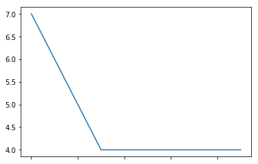

```python
# now try again
player_df["player_name"].value_counts().head(10).plot()

# this doesnt make sense, lets try another graph
```

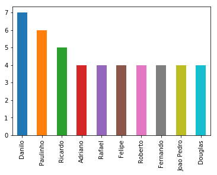

```python
player_df["player_name"].value_counts().head(10).plot(kind="bar")
```

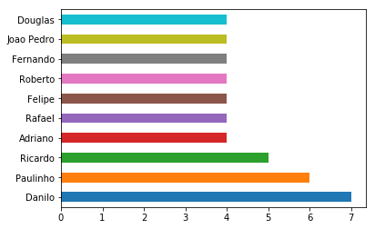

```python
# how about horizontal bars
player_df["player_name"].value_counts().head(10).plot(kind="barh")
```

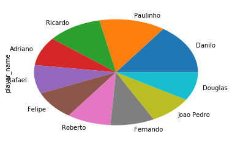

```python
# and pie charts
player_df["player_name"].value_counts().head(10).plot(kind="pie")
```

```python
# let's fetch player attributes
# your turn to fetch the data as a DataFrame from the Player_Attributes table
# name the dataframe pattr_df
```

```python
# your turn to do some analysis on pattr_df
# look at some attributes and find the best/worst players for different attributes
# find 5 different insights
```

```python
# create 5 different univariate plots that can tell us something useful about the players
```

# Is There More to Pandas?

- of course! we just scratched the surface.
  - There is multivariate graphs, aggregations, machine learning ... etc
- We can do much more complex visualizations, see [last year's marathon slides](http://qmisr.github.io/mis492/marathon2018)
- Also check out the [tutorials on datacamp](http://datacamp.com), where you can learn more about machine learning, forcasting, financial analysis, and much more!

# Using Jupyter Notebook

- Notice how you can use Jupyter notebook as a decision support system
- Power users typically take advantage of such tool, and must learn programmign languages.
- Most likely you will be working with data you only are authorized to look at, and you cannot get outsiders to do the analysis for you.

# Let's Try To Create a Web Application

- Let's start with flask (is this a micro or fullstack framework? whats the difference?)
- We will use repl.it for easy deployment, try to do the same thing from you home computer.
- Sqlite doesn't handle network connections, we have to upload to repl.it
- Signup to repl.it if you haven't and follow you instructor on how to build a simple web application.

# The Application Works, Let's Show Some Data

- Micro framework get out of your way, so you connect and fetch data as you normally would.

  ```
  # You add this to the index view function to fetch the data as a list of tuples
  import sqlite3
  conn = sqlite3.connect("database.sqlite")
  cur = conn.execute("SELECT * FROM player")
  result = cur.fetchall()
  ```

# Templates

- Most frameworks will have templating systems
- After generating data from the view function, you send it to the template to include the data in the HTML
- We send the data to the template using:

```
return render_template('index.html',result=result)
```

# Template HTML

- The template will have commands that allow you to iterate over data and display it
- Notice what we did in index.html:

  ```
  <h1>Player List</h1>
    <ol>
        {% for record in result %}
        <li>{{ record[2] }}: {{ record[1] }}</li>
        {% endfor %}
    </ol>
  ```

  ### Try to change the HTML template to make the page look better. Can you make a table?

# Using Pandas With Flask

- Before you can use Pandas with Flask, Add the library to the web app
- Open requirements.txt file and add the following line:

  ```
  pandas==0.23.4
  ```

We are telling flask we want to use pandas version 0.23.4, and it will install the necessary files.

# Let's Add Our Own View

- Create a new function in index.py

```
# put these imports in the otp of the file
import sqlite3
import pandas as pd

# add this somewhere in index.py
@web_site.route('/pandas/')
def pandas():
  conn = sqlite3.connect("database.sqlite")
  df = pd.read_sql("SELECT * FROM Player_Attributes limit 10", conn)
  return render_template('pandas.html',result=df.to_html())
```

# What is Missing?

- You get an error when you try to open the path /pandas/
- We created the view that prepares the data, but how are we going to show the data?
- This is where we use and HTML template.
- Create the file pandas.html:

```
<html>
    <body>
        {{ result|safe }}
    </body>
</html>
```

# Improving The Look And Feel

- Best done using CSS
- Try to investigate how you can do that on your own

# What Can You Do With Flask Now?

- Reports and Dashboard
- Need to display charts and visualizations
- More information on https://galaxydatatech.com/2018/03/31/passing-dataframe-web-page/
- App can be found at https://repl.it/@dralmarzouq/flask-db-app

# Web Application Can Produce Graphs

- You can include these graphs in HTML templates

```
@web_site.route('/fig/')
def fig():
  conn = sqlite3.connect("database.sqlite")
  df = pd.read_sql("SELECT * FROM Player_Attributes limit 100", conn)
  g = df["preferred_foot"].value_counts().plot(kind="pie")
  fig = g.figure
  img = BytesIO()
  fig.savefig(img)
  img.seek(0)
  return send_file(img, mimetype='image/png')
```

# Result From Web App

[figure not shown]

# Full Stack Framework

- Python has Django
- The [documentation is excellent](https://www.djangoproject.com)
- Has its own way of doing things that you need to lear
- Let's see how by building an application from a schema
- Highly recommend you explore it as an option, might offer a course if enough requests come in.

# Django MVC Model

- Model: Describes the data classes, corresponds to entities in ERD
- View: What you see on the browser, the HTML template part
- Controler: The logic and flow of the application, the view functions

### When building a Django web application, you build all three and combine them into an application

# ERD to Implement

[figure not shown]

# Application Walkthrough

- Signup to repl.it and log in
- Create a new repl, then search for Django
- Follow along and create your first Django web application

# The Final Application

Can be found at https://repl.it/@dralmarzouq/fullstack

# Recommended resources to read

- [Python resources](http://bit.ly/pyc_main), textbook chapters and links to useful resources compiled by Dr. AlMarzouq
- [The hitchhiker's guide to python](http://docs.python-guide.org/en/latest/), excellent resource to know how to perform certain tasks in python
- [Awsome python list](https://github.com/vinta/awesome-python), list of resources on how to perform certain tasks in python.
- [Python for Data Science List](https://github.com/ujjwalkarn/DataSciencePython), list of resources in python focusing on topics in data science.
- [List of interesting jupyter notebooks](https://github.com/jupyter/jupyter/wiki/A-gallery-of-interesting-Jupyter-Notebooks), see how others have solved data analysis problems and shared their code.
- [Social network analysis list](https://github.com/briatte/awesome-network-analysis), list of useful resources on social network analysis.
- [Real Python](https://realpython.com), tutorials and video that take you from a beginner to a proficient Python user.
- [Data Camp](http://datacamp.com), educational platform that takes you from a beginner Python user, to a data scientest using tutorial, daily practice, and projects. Other technologies include R, SQL, and Git. Highly recommended.
- [Azure Notebooks](https://notebooks.azure.com), check the featured projects section.
- [Code Academy](https://www.codecademy.com/learn/learn-python-3), good place to start learning python.
- [Data Quest Jupyter Tutorials](https://www.dataquest.io/blog/jupyter-notebook-tutorial/)

# Thank you

### Mohammad AlMarzouq

Send your questions to

almarzouq@cba.edu.kw

## We'd like to know your thoughts about the marathon training sessions, and what you learned:

[Please answer our survey](http://bit.ly/maras2019_s2)